# Statistique décisionnelles - TP1

Charles Vin

# Exercice 1

## Question 1

### Donnée

Soit $(X_1, ..., X_n)$ iid. de vecteur loi $p$.

Soit $p_n$ vecteur loi d’une $Unif([0,1.5])$.

On découpera l’intervale en 5 intervalles uniformes de longueur $0.3$ (de la forme $[a;b[$)

Calculons $\bar{p}_n$ en comptant les valeur dans chaques intervales

```r
valeur = c(0.02,0.02,0.07,0.07,0.07,0.09,0.11,0.13,0.16,0.16, 0.2,0.2,0.21,0.25,0.29,0.32,0.35,0.35,0.37,0.37, 0.38,0.4,0.4,0.41,0.47,0.49,0.54,0.55,0.59,0.6, 0.68,0.68,0.7,0.73,0.75,0.79,0.79,0.8,0.81,0.81, 0.86,0.89,1.03,1.04,1.04,1.09,1.12,1.21,1.33,1.42)
n = 50

# Création de la table et comptage des valeurs dans l'intervale
interval_table = data.frame(
  table(
    cut(valeur,
        right = FALSE, # [a,b[
        breaks=seq(0, 1.5, length.out = 6),
        labels=c("[0;0.3[","[0.3 ; 0.6[","[0.6 ; 0.9[","[0.9;1.2[","[1.2;1.5[")
      )
  )
)
colnames(interval_table)<-c("Intervale","Freq") # On change le nom des colonnes.

p_n_bar = interval_table$Freq # On prépare p_n_bar
interval_table
```

| Intervale | Freq |
| --- | --- |
| [0;0.3[ | 15 |
| [0.3 ; 0.6[ | 14 |
| [0.6 ; 0.9[ | 13 |
| [0.9;1.2[ | 5 |
| [1.2;1.5[ | 3 |

Générons $p_n$ indiquant les probabilité d’une loi $Unif([0;1.5])$ d’être dans chaque intervale.

```r
# On initialise les intervales
intervals = list()
p_n = c()
a = c(0, 0.3, 0.6, 0.9, 1.2)
b = c(0.3, 0.6, 0.9, 1.2, 1.5)

# Définition des intervales et calcul de p_n Uniforme
# Pas trouver de méthode sans boucle for :(
for (i in 1:length(a)) {
  intervals[[i]]= c(a[i], b[i])
  p_n = c(p_n,
          punif(intervals[[i]][2], max = 1.5) - punif(intervals[[i]][1], max = 1.5))
}
p_n
```

```
[1] 0.2 0.2 0.2 0.2 0.2
```

Ajoutons le à la data frame `interval_table` avec également les $n*p_{n,i}$ :

```r
interval_table["p_n"] = p_n
interval_table["n*p_i"] = p_n*n
interval_table
```

| Intervale | Freq | p_n | n*p_i |
| --- | --- | --- | --- |
| [0;0.3[ | 15 | 0.2 | 10 |
| [0.3 ; 0.6[ | 14 | 0.2 | 10 |
| [0.6 ; 0.9[ | 13 | 0.2 | 10 |
| [0.9;1.2[ | 5 | 0.2 | 10 |
| [1.2;1.5[ | 3 | 0.2 | 10 |

### Condition

- On a regroupé les valeurs pour créer des classes et tester l’adéquation à une **loi discrète**
- $n=50$ et les $np_{n,i} \geq 5$

Les conditions du test du $\mathcal{X}^2$ d’adéquation sont remplis.

### Test

```r
chisq.test(p_n_bar, p=p_n)
```

```
    Chi-squared test for given probabilities

data:  p_n_bar
X-squared = 12.4, df = 4, p-value = 0.01461
```

On retrouve :

- La statistique de test $D(p_n, \bar{p_n}) = \sum_{k=0}^{5} \frac{(N_{n,k } - n*p_{n,k})^2}{n*p_{n,k}} = 12.4$
- Et la $p-valeur = 0.01461$

### Conclusion

Au vu de la p-valeur, on rejette $H_0$. Les $X_i$ ne suivent pas une loi Uniforme sur $[0;1.5$.

## Question 2

### Donnée

Soit $(X_1, ..., X_n)$ iid. de vecteur loi $p$.

Soit $Y$ une variable aléatoire de densité $f(x) = \cos(x) \mathbb{1}_{x \in [0; pi/2]}$. Soit $p_n$ vecteur loi de $Y$ sur les intervales précédents.

On a donc :
$$P(a<Y<b) = \int_a^b cos(x) \mathbb{1}_{[a,b] \subset [0;
pi/2]}dx = sin(b) - sin(a) \mathbb{1}_{[a,b] \subset [0; pi/2]}$$
Dans notre cas tous nos intervales sont inclus dans $[0,pi/2]$

Calculons $p_n$ avec cette nouvelle densité :

```r
p_n = c()
for (i in 1:length(a)) {
  p_n = c(p_n,
          sin(intervals[[i]][2]) - sin(intervals[[i]][1])
        )
}
interval_table["p_n"] = p_n
interval_table["n*p_i"] = p_n*n
interval_table
```

| Intervale | Freq | p_n | n*p_i |
| --- | --- | --- | --- |
| [0;0.3[ | 15 | 0.2955202 | 14.776010 |
| [0.3 ; 0.6[ | 14 | 0.2691223 | 13.456113 |
| [0.6 ; 0.9[ | 13 | 0.2186844 | 10.934222 |
| [0.9;1.2[ | 5 | 0.1487122 | 7.435609 |
| [1.2;1.5[ | 3 | 0.0654559 | 3.272795 |

### Condition

On remarque que les $np_{n,i}$ ne sont pas tous supérieur à $5$. Fusionnons donc les deux dernières classes en reprenant les étapes d’avant.

```r
# Création de la table et comptage des valeurs dans l'intervale
interval_table = data.frame(
  table(
    cut(valeur,
        right = FALSE,
        breaks=c(0,0.3, 0.6,0.9,1.5),
        labels=c("[0;0.3[","[0.3 ; 0.6[","[0.6 ; 0.9[","[0.9;1.5[")
      )
  )
)
colnames(interval_table)<-c("Intervale","Freq") # On change le nom des colonnes.

p_n_bar = interval_table$Freq # On prépare p_n_bar
interval_table
```

| Intervale | Freq |
| --- | --- |
| [0;0.3[ | 15 |
| [0.3 ; 0.6[ | 14 |
| [0.6 ; 0.9[ | 13 |
| [0.9;1.5[ | 8 |

```r
intervals = list()
p_n = c()
a = c(0, 0.3, 0.6, 0.9)
b = c(0.3, 0.6, 0.9, 1.5)

# Redéfinition des intervales
for (i in 1:length(a)) {
  intervals[[i]]= c(a[i], b[i])
}

# Calcul des p_n de chaque intervale
for (i in 1:(length(a)-1)) {
  p_n = c(p_n,
          sin(intervals[[i]][2]) - sin(intervals[[i]][1])
        )
}
p_n = c(p_n, 1-sum(p_n)) # En veillant à ce que la somme fasse 1

#On remet le tout dans notre tableau final
interval_table["p_n"] = p_n
interval_table["n*p_i"] = p_n*n
interval_table
```

| Intervale | Freq | p_n | n*p_i |
| --- | --- | --- | --- |
| [0;0.3[ | 15 | 0.2955202 | 14.77601 |
| [0.3 ; 0.6[ | 14 | 0.2691223 | 13.45611 |
| [0.6 ; 0.9[ | 13 | 0.2186844 | 10.93422 |
| [0.9;1.5[ | 8 | 0.2166731 | 10.83365 |

Nos conditions sont maintenant remplis !

### Hypothèse

- $H_0 = p = p_n$ : la loi des $X_i$ est la même que celle des $Y_i$
- $H_0 = p \neq p_n$ : la loi des $X_i$ n’est pas la même que celle des $Y_i$

### Test

```r
chisq.test(p_n_bar, p=p_n)
```

```
    Chi-squared test for given probabilities

data:  p_n_bar
X-squared = 1.1568, df = 3, p-value = 0.7634
```

On retrouve :

- La statistique de test $D(p_n, \bar{p_n}) = \sum_{k=0}^{5} \frac{(N_{n,k } - n*p_{n,k})^2}{n*p_{n,k}} = 1.15$
- Et la $p-valeur = 0.7634$

### Conclusion

Au vu de la p-valeur, on conserve $H_0$. Les $X_i$ semble suivre une densité $f(x) = cos(x)\mathbb{1}_{x \in [0,pi/2]}$.

# Exercice 2

## Enoncé (+code)

Un jardinier souhaite évaluer efficacité de la mise en place d’un paillage. Cette technique consiste à mettre de la paille au niveau de chaque pied pour mieux retenir l’humidité. On suppose que cela aurait une influence sur le poids des tomates.

Pour cela, le jardinier a mis du paillage uniquement d’un côté de sa serre. Le tout en plantant les semis d’un même lots et en arrosant uniformément des deux côtés.

```r
# echo=FALSE <- permet de cacher le code pour obtenir un énoncé propre.
n_1=20
m = 200
sigma = 5

ech = round(rnorm(n_1, m, sigma), 1)
X_n_bar = round(mean(ech),2)
V_n = round(var(ech),2)

cat(ech)
```

```
204.4 197.1 193.4 201.2 204.2 201.3 202.1 197.7 197.2 195.3 192 198.1 200 201.4 206.6 202 203.2 198.5 201.7 204.1
```

```r
cat(paste("\nIl y a eu", n_1, "tomates"))
```

```
Il y a eu 20 tomates
```

```r
cat(paste("\nLa moyenne vaut :", X_n_bar))
```

```
La moyenne vaut : 200.07
```

```r
cat(paste("\nLa variance vaut :", V_n))
```

```
La variance vaut : 14.79
```

```r
# echo=FALSE <- permet de cacher le code pour obtenir un énoncé propre.
n_2 = 22
ech_paillage = round(rnorm(n_2, m+10, sigma), 1)
X_n_bar_paillage = round(mean(ech_paillage),2)
V_n_paillage = round(var(ech_paillage),2)

cat(ech_paillage)
```

```
202.9 209.6 202.1 207.6 208 208.7 215.8 210.4 208.4 219.6 204.8 208 209.5 198.2 211.2 206.3 212.8 206.6 212.7 210.4 211.6 208.9
```

```r
cat(paste("\nIl y a eu", n_2, "tomates"))
```

```
Il y a eu 22 tomates
```

```r
cat(paste("\nLa moyenne vaut :", X_n_bar_paillage))
```

```
La moyenne vaut : 208.82
```

```r
cat(paste("\nLa variance vaut :", V_n_paillage))
```

```
La variance vaut : 20.89
```

1. D’après sa balance/caisse enregistreuse, le poids des tomates récolté lors des années précédentes sans paillage suit une loi normale de moyenne $m=200$ et de variance $\sigma^2=25$. Vérifier que c’est toujours le cas cette année avec $\alpha = 5\%$ de se tromper.

Pour vous aider, voici la table des valeurs de la fonction de répartition d’une $\mathcal{N}(200,5^2)$ pour les valeurs de l’échantillon.

```r
# echo=FALSE <- permet de cacher le code pour obtenir un énoncé propre.
data.frame(
  t = sort(ech),
  "F_X(t)" = pnorm(sort(ech), 200, 5)
)
```

| t | F_X.t. |
| --- | --- |
| 192.0 | 0.05479929 |
| 193.4 | 0.09341751 |
| 195.3 | 0.17360878 |
| 197.1 | 0.28095731 |
| 197.2 | 0.28773972 |
| 197.7 | 0.32275811 |
| 198.1 | 0.35197271 |
| 198.5 | 0.38208858 |
| 200.0 | 0.50000000 |
| 201.2 | 0.59483487 |

[output cut: 10 more lines]

2. Supposons maintenant que la moyenne sur les années précédentes n’est pas accessible à cause de l’écran cassé de la balance/caisse enregistreuse. En supposant que le paillage n’est pas changer la variance, tester au niveau $\alpha = 5\%$ si celui-ci a augmenté la moyenne.

## Correction

### Question 1

Effectuons un test d’adéquation de Kolmogorov-Smirnov.

#### Donnée

Soit $(X_1, ..., X_n)$ iid. de fonction de répartition $F_X$ inconnu.

#### Conditions

- Les $X_i$ viennent d’une loi continue. Les valeurs répétées viennent des arrondis.
- $n$ est petit, on utilisera la version non asymptotique.

#### Hypothèse

- $H_0: F_X = F_0$ Le poids des tomates récoltés sans paillage cette année suit la même loi que les années précédentes
- $H_1: F_X \neq F_0$ Le poids des tomates récoltés sans paillage cette année ne suit pas la même loi que les années précédentes

#### Statistique de test

$$D = \sup_{t \in \mathbb{R}} \{\frac{1}{n} \sum_{i=1}^{n} 1_{X_i \leq t}
- F_0(t)\} \\
= \max _{1 \leq i \leq n} ( \max ( \left| \frac{i}{n} - F_0(t) \right|
, \left| \frac{i-1}{n}- F_0(t)) \right| ))$$
#### Zone de rejet

- Sous $H_0 : D \to 0$
- Sous $H_1 : D \to h$
  $$\mathcal{R} = \{ D \geq 0.2941\}$$
  #### Calcul de la statistique de test

```r
  ks.test(ech, pnorm, m, sigma)
```

```
    One-sample Kolmogorov-Smirnov test

data:  ech
D = 0.14483, p-value = 0.7429
alternative hypothesis: two-sided
```

On obtient une statistique de test $D \not\in \mathcal{R}$. On conserve $H_0$, la poids des tomates suit la même loi que les années précédentes.

### Question 2

Nous allons effectuer un test de Student à 2 échantillons gaussien de variance égale

#### Données

- Soit $X_1, ..., X_{n_1}$ variables aléatoires iid. $\mathcal{N}(m_1, 5^2)$ représentant le poids de la ième tomate récoltée sans paillage
- Soit $Y_1, ..., Y_{n_2}$ variables aléatoires iid. $\mathcal{N}(m_2, 5^2)$ représentant le poids de la ième tomate récoltée avec paillage
- Les échantillons sont indépendants.

#### Hypothèse

- $H_0: m_1 = m_2$ Le poids des tomates récoltés sans paillage à même loi que celle récoltée avec paillage. Le paillage n’a aucun effet sur le poids moyen des tomates
- $H_1: m_1 < m_2$ Le paillages augmente le poids moyen des tomates

#### Statistique de test

$$D = \frac{1}{\sqrt[]{\frac{1}{n_1} + \frac{1}{n_2}}}
\frac{\bar{X}_{n_1} - \bar{Y}_{n_2}}{\sqrt[]{W}}$$
Avec $W = \frac{(n_1 - 1) V_{n_1}^X + (n_2 - 1) V_{n_2}^Y}{n_1 + n_2 - 2}$

#### Zone de rejet

- Sous $H_0 : m_1 = m_2$
  $$D \sim \mathcal{T}(n_1+n_2-2)$$
- Sous $H_1 : m_1 < m_2, D$ prend des valeurs plus petites que sous $H_0$.
  $$\mathcal{R} = \{D < h_\alpha\}$$
  avec $h_\alpha$ quantile d’ordre alpha d’une $\mathcal{T}(n_1 + n_2 -2)$

#### Calcul de la statistique de test

Dans notre cas :

```r
W = (1/(n_1 + n_2 - 2))*((n_1 - 1)*V_n + (n_2 -1) * V_n_paillage)
 str = paste(
   "W = \\frac{(",n_1," - 1)",
   V_n,
   " + (",n_2,"- 1)",
   V_n_paillage,
   "}{",n_1," + ",n_2," - 2} = ",
   W
 )
writeLines(c("$$", str, "$$"))
```

$$W = \frac{( 20 - 1) 14.79 + ( 22 - 1) 20.89 }{ 20 + 22 - 2}
= 17.9925$$

Et :

```r
D = ((1)/(sqrt(1/n_1 + 1/n_2))) * ((X_n_bar - X_n_bar_paillage)/sqrt(W))

 str = paste("  D =
          \\frac{1}{\\sqrt[]{\\frac{1}{",n_1,"} + \\frac{1}{",n_2,"}}}
          \\frac{",X_n_bar," - ",X_n_bar_paillage,"}{\\sqrt[]{",W,"}} ="
  , round(D,4)
)
writeLines(c("$$", str, "$$"))
```

$$D =
\frac{1}{\sqrt[]{\frac{1}{ 20 } + \frac{1}{ 22 }}}
\frac{ 200.07 - 208.82 }{\sqrt[]{ 17.9925 }} = -6.6767$$

```r
t.test(ech, ech_paillage, alternative = "greater", var.equal = TRUE)
```

```
    Two Sample t-test

data:  ech and ech_paillage
t = -6.6751, df = 40, p-value = 1
alternative hypothesis: true difference in means is greater than 0
95 percent confidence interval:
 -10.95441       Inf
sample estimates:
mean of x mean of y
 200.0750  208.8227
```

(Les différences de valeurs entre le calcul à la main et fait par R viennent des arrondies sur les moyennes et variances)

# Exercice 3

Définissons la fonction qui estime un quantile à partir d’une proba et d’un échantillon.

```r
Q = function(n, p, ech) {
  return(ech[as.integer(p*n)])
}
```

## Question 1

Pour $n=1000$ il faut regarder
$$Q_n(0.95) = X_{(n*0.95)} = X_{(950)}\\
Q_n(0.975) = X_{(n*0.975)} = X_{(975)}$$

## Question 3

```r
n = 10000
sorted_echantillon = sort(rnorm(n, 0, 1)) # Tirage de n loi normale + tri dans l'ordre croissant
p = seq(0.8, 0.95, 0.01)
df = data.frame(
  proba = p,
  estimated_quantile = Q(n, p, sorted_echantillon),
  real_quantile = qnorm(p)
)
df["error"] = abs(df$estimated_quantile - df$real_quantile)
df
```

| proba | estimated_quantile | real_quantile | error |
| --- | --- | --- | --- |
| 0.80 | 0.8074715 | 0.8416212 | 0.03414975 |
| 0.81 | 0.8416756 | 0.8778963 | 0.03622067 |
| 0.82 | 0.8860235 | 0.9153651 | 0.02934157 |
| 0.83 | 0.9248255 | 0.9541653 | 0.02933978 |
| 0.84 | 0.9672286 | 0.9944579 | 0.02722926 |
| 0.85 | 1.0127273 | 1.0364334 | 0.02370605 |
| 0.86 | 1.0570411 | 1.0803193 | 0.02327828 |
| 0.87 | 1.0977691 | 1.1263911 | 0.02862203 |
| 0.88 | 1.1437993 | 1.1749868 | 0.03118747 |
| 0.89 | 1.1996640 | 1.2265281 | 0.02686415 |

[output cut: 6 more lines]

Testons $\forall p \in [0,1]$ et traçons les deux fonctiondes de répartiton. En rouge la vrais fonction de répartition, en noir l’empirique.

```r
p = seq(0.01, 0.99, 0.01) #Cette fois ci pour tout p en évitant les frontière qui provoque des erreurs
df = data.frame(
  proba = p,
  estimated_quantile = Q(n, p, sorted_echantillon),
  real_quantile = qnorm(p, 0, 1)
)
plot(df$estimated_quantile,df$proba, xlab="x", ylab="Probabilité", type="l", xlim=c(-2,2), ylim=c(0,1))
title("Fonction de répartition empirique/réel")
```

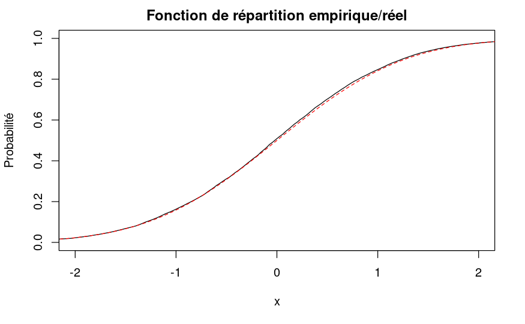

```r
lines(df$real_quantile, df$proba, col="red", lty=2)
```

Les deux fonctions de répartiton se superpose !

## Question 4

### Calcul des échantillons

```r
p = seq(0.8, 0.95, 0.01)
sorted_echantillon = sort(runif(n, 0, 1) + runif(n,0,1))
df = data.frame(
  proba = p,
  estimated_quantile = Q(n, p, sorted_echantillon)
)
df
```

| proba | estimated_quantile |
| --- | --- |
| 0.80 | 1.377101 |
| 0.81 | 1.393718 |
| 0.82 | 1.410004 |
| 0.83 | 1.426740 |
| 0.84 | 1.446631 |
| 0.85 | 1.465139 |
| 0.86 | 1.482488 |
| 0.87 | 1.499359 |
| 0.88 | 1.519823 |
| 0.89 | 1.540843 |

[output cut: 6 more lines]

### Fonction de répartition empirique pour $p \in [0.8, 0.95]$

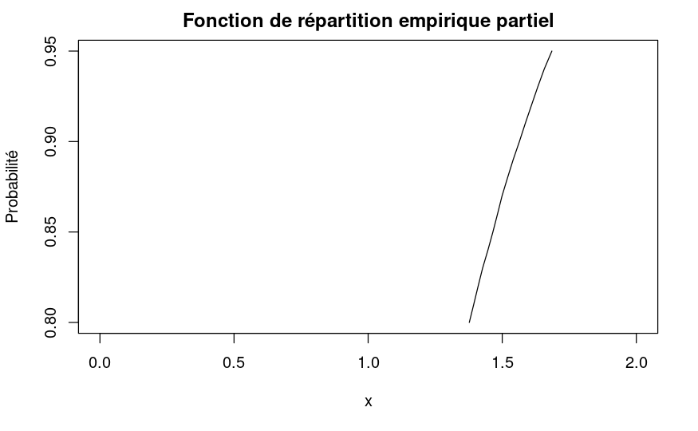

```r
plot(df$estimated_quantile,df$proba, xlab="x", ylab="Probabilité", type="l", xlim=c(0,2))
title("Fonction de répartition empirique partiel")
```

### Histograme des estimation pour $p \in [0.8, 0.95]$

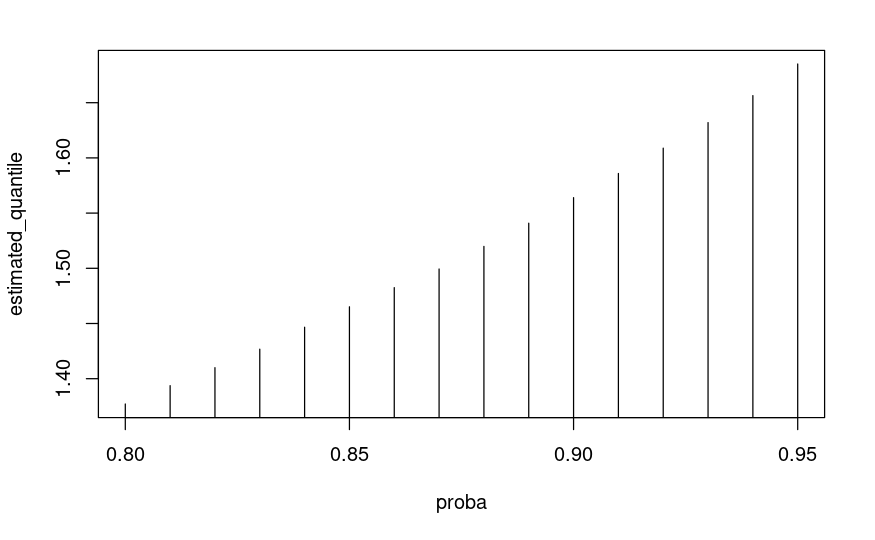

```r
plot(df, type="hist")
```

### Fonction de répartition empirique complète

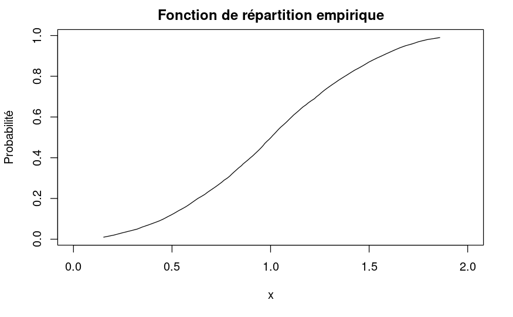

```r
p = seq(0.01, 0.99, 0.01)
df = data.frame(
  proba = p,
  estimated_quantile = Q(n, p, sorted_echantillon)
)
plot(df$estimated_quantile,df$proba, xlab="x", ylab="Probabilité", type="l", xlim=c(0,2))
title("Fonction de répartition empirique")
```

## Question 5

$$h_{10} = \sup_{t \in \mathbb{R}} \{\frac{1}{10} \sum_{i=1}^{10} 1_{U_i
\leq t} - t\} \\
= \max _{1 \leq i \leq n} ( \max ( \left| \frac{i}{n} - t \right| ,
\left| \frac{i-1}{n}- t) \right| ))$$
Fonction pour obtenir un échantillon de `sample_lenght` statistique de KS de paramètre `n`.

```r
ks_stat_unif = function(n, sample_lenght){
  ks_ech = c()
  # On créé un échantillon de longueur sample_lenght
  for(i in 1:sample_lenght){
    tmp = c()
    # On effectue un tirage de n loi uniforme pour calculer la stat de test
    sorted_unif = sort(runif(n, 0, 1))

    # Puis on cherche le max suivant la formule précédante
    for(i in 1:n){
      tmp = c(tmp,max(
              abs(i/n - sorted_unif[i]),
              abs((i-1)/n - sorted_unif[i])
            )
        )
    }
    ks_ech = c(ks_ech, max(tmp))
  }
  return(ks_ech)
}
```

### Calcul des échantillons

```r
p = seq(0.8, 0.95, 0.01)
sorted_echantillon = sort(ks_stat_unif(10, n)) #tirage de 10 000 stat de KS de paramètre 10
df = data.frame(
  proba = p,
  estimated_quantile = Q(n, p, sorted_echantillon)
)
```

### Fonction de répartition empirique pour $p \in [0.8, 0.95]$

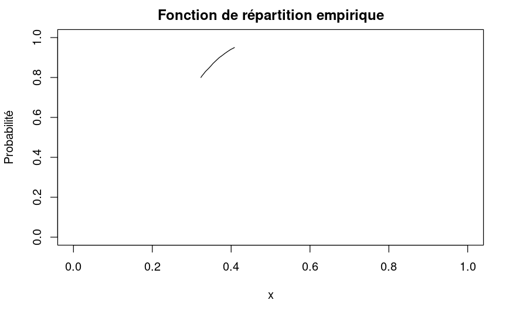

```r
plot(df$estimated_quantile,df$proba, xlab="x", ylab="Probabilité", type="l", xlim=c(0,1), ylim=c(0,1))
title("Fonction de répartition empirique")
```

### Fonction de répartition empirique complète

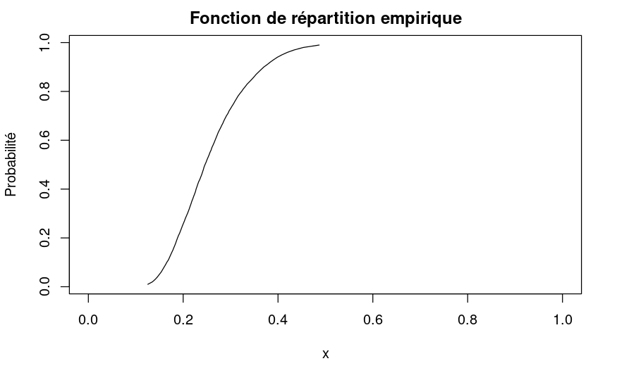

```r
p = seq(0.01, 0.99, 0.01)
df = data.frame(
  proba = p,
  estimated_quantile = Q(n, p, sorted_echantillon)
)
plot(df$estimated_quantile,df$proba, xlab="x", ylab="Probabilité", type="l", xlim=c(0,1))
title("Fonction de répartition empirique")
```

### Comparaison avec les quantiles de notre table

```r
df[c(80, 90, 95, 98, 99),]
```

|  | proba | estimated_quantile |
| --- | --- | --- |
| 80 | 0.80 | 0.3232211 |
| 90 | 0.90 | 0.3700411 |
| 95 | 0.95 | 0.4083576 |
| 98 | 0.98 | 0.4532467 |
| 99 | 0.99 | 0.4867980 |

Cela correspond bien à ce qu’on a dans notre table avec une précision à $10^{-2}$

# Question 6

Fonction pour obtenir un échantillon de `sample_lenght` statistique de Lilliefors de paramètre `n`.

```r
lilliefors_stat = function(n, sample_lenght){
  lilliefors_ech = c()
  # On créé un échantillon de longueur sample_lenght
  for(i in 1:sample_lenght){
    tmp = c()
    # On effectue un tirage de n loi normale pour calculer la stat de test
    sorted_norm = sort(rnorm(n, 0, 1))
    X_bar = mean(sorted_norm)
    V_n = var(sorted_norm)

    # Puis on cherche le max suivant la formule précédante
    for(i in 1:n){
      tmp = c(tmp,max(
              abs(i/n - pnorm(sorted_norm[i], X_bar, V_n)),
              abs((i-1)/n - pnorm(sorted_norm[i], X_bar, V_n))
            )
        )
    }
    lilliefors_ech = c(lilliefors_ech, max(tmp))
  }
  return(lilliefors_ech)
}
```

### Calcul des échantillons

```r
p = seq(0.8, 0.95, 0.01)
sorted_echantillon = sort(lilliefors_stat(10, n)) #tirage de 10 000 stat de Lilliefors de paramètre 10
df = data.frame(
  proba = p,
  estimated_quantile = Q(n, p, sorted_echantillon)
)
```

### Fonction de répartition empirique pour $p \in [0.8, 0.95]$

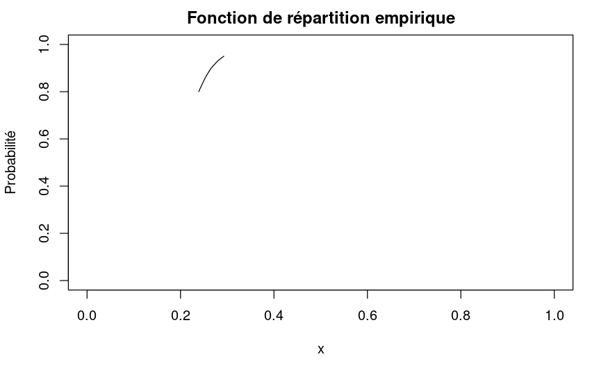

```r
plot(df$estimated_quantile,df$proba, xlab="x", ylab="Probabilité", type="l", xlim=c(0,1), ylim=c(0,1))
title("Fonction de répartition empirique")
```

### Fonction de répartition empirique complète

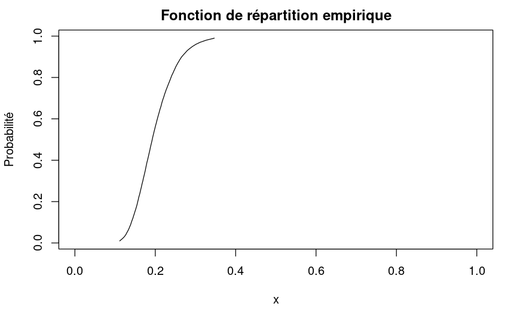

```r
p = seq(0.01, 0.99, 0.01)
df = data.frame(
  proba = p,
  estimated_quantile = Q(n, p, sorted_echantillon)
)
plot(df$estimated_quantile,df$proba, xlab="x", ylab="Probabilité", type="l", xlim=c(0,1))
title("Fonction de répartition empirique")
```

### Comparaison avec les quantiles de notre table

```r
df[c(90, 95, 99),]
```

|  | proba | estimated_quantile |
| --- | --- | --- |
| 90 | 0.90 | 0.2657894 |
| 95 | 0.95 | 0.2926140 |
| 99 | 0.99 | 0.3468743 |

Cela correspond pas vraiment à ce qu’il y a dans notre table. Essayons d’augmenter l’échantillon.

```r
p = c(0.90, 0.95, 0.99)
n = 10000
sorted_echantillon = sort(lilliefors_stat(10, n*10))
sorted_echantillon_small = sort(lilliefors_stat(10, n))
df = data.frame(
  proba = p,
  estimated_quantile_big_n = Q(n*10, p, sorted_echantillon),
  estimated_quantile_smaller_n = Q(n, p, sorted_echantillon_small)
)
df
```

| proba | estimated_quantile_big_n | estimated_quantile_smaller_n |
| --- | --- | --- |
| 0.90 | 0.2669777 | 0.2669665 |
| 0.95 | 0.2921574 | 0.2923641 |
| 0.99 | 0.3464007 | 0.3435808 |